# rarefaction slides

## Rarefaction in multilayer networks: traits, interactions and species

- Tools for reproducibility in a multiple computing languages environment
- Jupyter, git, open-source software: R, octave, python...
- Examples around sampling, spatial data, centrality

## Acknowledgements

### Francisco Baldo

### Catalina Chaparro

### Malena Sabatino

### Ali Rezaee Vahdati

### References

#### How to compare species richness among sets with different sample size instead of comparing absolute number of species

##### Sanders, Howard L. "Marine Benthic Diversity: A Comparative Study". (1968). The American Naturalist. 102:243.

#### How to detect scale-dependence species richness among sets with different sample size instead of comparing absolute number of species

##### ChaseJ. M., et al. (2018). Embracing scale-dependence to achieve a deeper understanding of biodiversity and its change across communities, (2018). Ecol. Lett., 21:1737-1751

#### Hill Numbers

##### Gotelli, N. J., Hsieh, T. C., Sander, E. L., & Colwell, R. K. (2014). Rarefaction and Extrapolation with Hill Numbers: A Framework for Sampling and Estimation in Species Diversity. Ecological Monographs, 84:45–67.

# QUESTIONS

## Scale-dependence: How do rarefaction curves cross in multilayer mutualistic networks?

## Centrality: How do we account for spatial and interaction network position?

# BACKGROUND

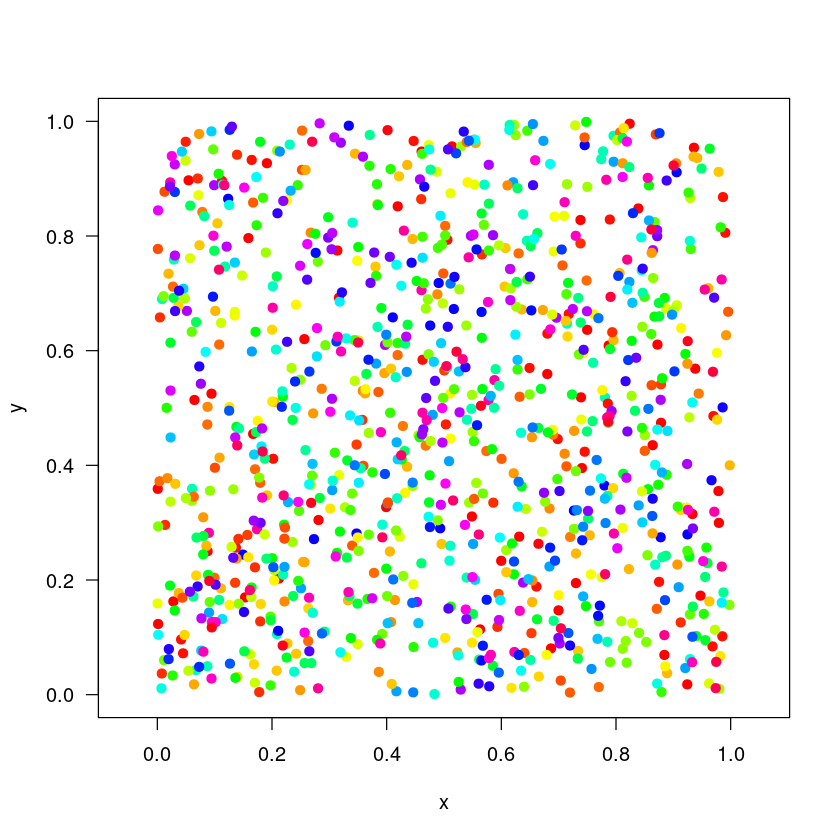

```r
### R -- SPATIAL DISTRIBUTION
### Chase et al plot -- scale-dependence
### https://cran.r-project.org/web/packages/mobsim/vignettes/Biodiversity_Changes.html

#install.packages("mobsim")
#library(mobsim)
library("mobsim") # Equivalent

S0 <- 100
N0 <- 1000
cv0 <- 0.5

sim_ref <- sim_poisson_community(s_pool = S0, n_sim = N0, sad_type = "lnorm",
sad_coef = list("cv_abund" = cv0), fix_s_sim = T)
plot(sim_ref)
```

```r
## R -- RICHNESS WITH DIFFERENT SAD
library("mobsim")

sim_lower_N <-  sim_poisson_community(s_pool = S0, n_sim = N0/2,

sad_type = "lnorm",sad_coef = list("cv_abund" = cv0))
sim_uneven <-  sim_poisson_community(s_pool = S0, n_sim = N0,

sad_type = "lnorm",sad_coef = list("cv_abund" = cv0*5),fix_s_sim = T)
curve_uneven <- spec_sample_curve(sim_uneven)
curve_ref    <- spec_sample_curve(sim_ref)
```

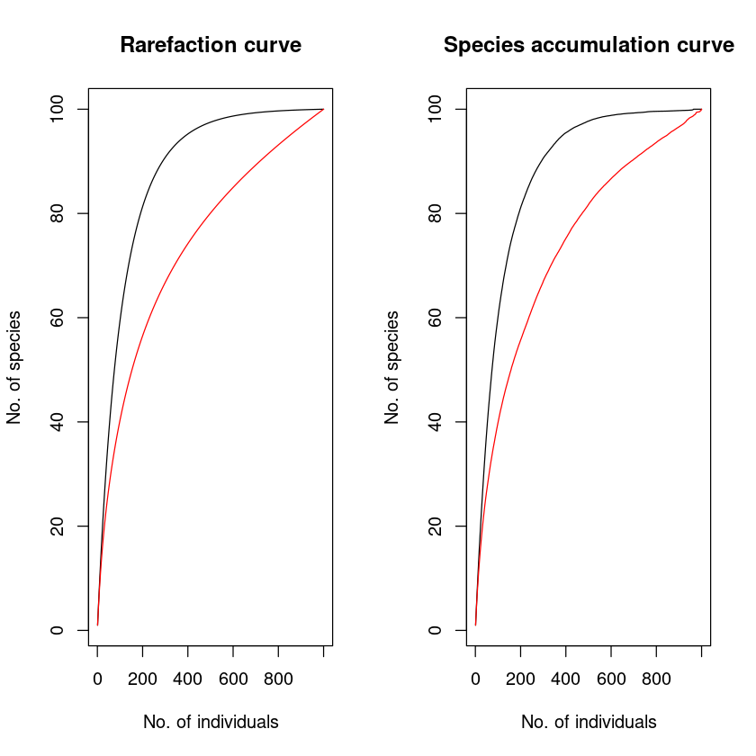

```r
par(mfrow = c(1,2))
plot(spec_rarefied ~ n, data = curve_ref, type = "l", main = "Rarefaction curve",
     xlab = "No. of individuals", ylab = "No. of species" )
lines(spec_rarefied ~ n, data = curve_uneven, col = "red")

plot(spec_accum ~ n, data = curve_ref, type = "l", main = "Species accumulation curve",
     xlab = "No. of individuals", ylab = "No. of species" )
lines(spec_accum ~ n, data = curve_uneven, col = "red")
```

# DATA

### Example Tandilia Hills System --- Argentinian Pampa

[figure not shown]

# CODE

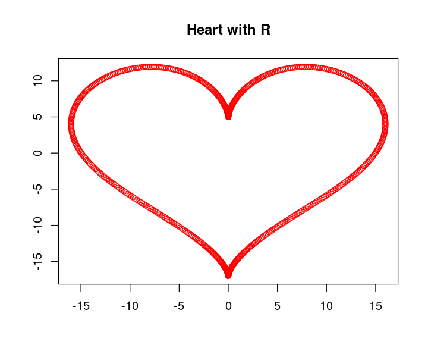

```r
options(repr.plot.width = 6)
options(repr.plot.height = 5)

t = seq(0, 2*pi, by = 0.01)
x = 16 * sin(t)^3
y = 13 * cos(t) - 5*cos(2*t) - 2*cos(3*t) - cos(4*t)
plot(x, y, main = "Heart with R", xlab = "", ylab = "", col = "red")
```

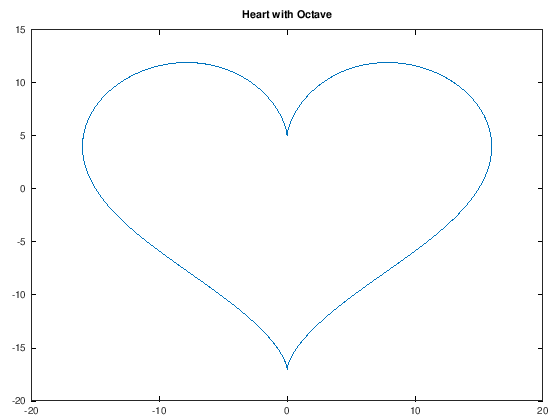

```r
graphics_toolkit();
available_graphics_toolkits();
loaded_graphics_toolkits();

graphics_toolkit("gnuplot")
t=-10:0.01:10;
x=16*(power(sin(t),3));
y=(13*cos(t))-(5*cos(2*t))-(2*cos(3*t))-(cos(4*t));
plot(x,y)
title("Heart with Octave", 'Color','k','fontsize',18)
```

[more hearts](https://datascience-enthusiast.com/Miscellaneous/Jupyter_R_Python_Julia_Octave.html)

### EXAMPLE: Octave -- Rarefaction species richness

```r
#NAME: RarefactionI.m
addpath(genpath(pwd))
#pkg install -forge statistics
pkg load statistics io
fid = fopen('./src/data/Pampa/Pampa_2020.csv');in = fscanf(fid,'%c');fclose(fid);# DATA
linesR = regexp(in,'(^,|)([^\n]+)', 'match');All = char(linesR);Forest = cell(length(All),1);wR = unique(linesR);
R = char(wR);# Print ALL Sierras
for k = 1:length(All);wHF = regexp(All(k,:),',');Forest(k,1) = All(k,1:wHF(1,1)-1);end
wF = unique_no_sort(Forest)# Print UNIQUE Sierras
```

```
wF =
{
  [1,1] = Sierra
  [1,2] = Piedra Alta
  [1,3] = Difuntito
  [1,4] = Difuntos
  [1,5] = Cinco cerros
  [1,6] = Volcan
  [1,7] = La Chata
  [1,8] = Barrosa
  [1,9] = La Brava
  [1,10] = Vigilancia
  [1,11] = El Morro
  [1,12] = La Paja
  [1,13] = Amarante
}
```

```r
for n = 2:length(wF);
#TypeOutput = zeros(length(R),4);#Type = zeros(1,1);#ForestType = zeros(1,1);
xR = zeros(1,1);wHR1 = zeros(1,1);cR = cellstr(wF(1,n));
xR = regexpcell(linesR,cR);ForestType = cell(length(xR),1);
    for j = 1:length(xR);
        wHR1 = regexp(All(xR(1,j),:),',');
        ForestType(j,1) = All(xR(1,j),wHR1(1,2)+1:wHR1(1,3)-1);
    end
    wFsam(1,n) = length(ForestType);
end
wFsam#Number interactions each site
```

```
wFsam =

     0   348   479   532   415   629   599   483   406   619   365   413   511
```

### Rarefaction Algorithm ------------------------------------------

- Pick up a sampled site
- Randomly select n subsamplings with or without replacement each with size of the least number of species or interactions from all the sampled sites
- Compare curves along subsamplings of equal size

```r
pkg load statistics
MIN = min(wFsam(1,2:end));
R=10;#Number of replicates
for rep = 1:R;
      U = zeros(1,2);
      for r = 1:MIN;
          S = unidrnd(length(xR),r,1)';#R replicates
          L = unique(ForestType(S(1,1:r)));
          U(r,1) = r;
          U(r,2) = length(L);
      end
end#rep
```

```
wF =
{
  [1,1] = Sierra
  [1,2] = Piedra Alta
  [1,3] = Difuntito
  [1,4] = Difuntos
  [1,5] = Cinco cerros
  [1,6] = Volcan
  [1,7] = La Chata
  [1,8] = Barrosa
  [1,9] = La Brava
  [1,10] = Vigilancia
  [1,11] = El Morro
  [1,12] = La Paja
  [1,13] = Amarante
}

wFsam =

     0   348   479   532   415   629   599   483   406   619   365   413   511

wFsam =

     0   348   479   532   415   629   599   483   406   619   365   413   511

wFsam =

     0   348   479   532   415   629   599   483   406   619   365   413   511

wFsam =

     0   348   479   532   415   629   599   483   406   619   365   413   511

wFsam =

     0   348   479   532   415   629   599   483   406   619   365   413   511

wFsam =

     0   348   479   532   415   629   599   483   406   619   365   413   511
```

[output cut: 9 more lines]

```
wFsam =

     0   348   479   532   415   629   599   483   406   619   365   413   511

wFsam =

     0   348   479   532   415   629   599   483   406   619   365   413   511

wFsam =

     0   348   479   532   415   629   599   483   406   619   365   413   511

wFsam =

     0   348   479   532   415   629   599   483   406   619   365   413   511
```

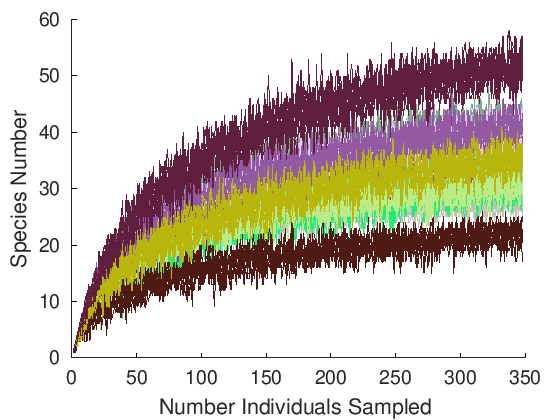

```r
## ALL Together
graphics_toolkit();
available_graphics_toolkits();
loaded_graphics_toolkits();
graphics_toolkit("gnuplot")
addpath(genpath(pwd))
pkg load statistics
fid = fopen('./data/Pampa/Pampa_2020.csv');in = fscanf(fid,'%c');fclose(fid);# DATA
linesR = regexp(in,'(^,|)([^\n]+)', 'match');All = char(linesR);Forest = cell(length(All),1);wR = unique(linesR);
R = char(wR);# Print ALL Sierras
for k = 1:length(All);wHF = regexp(All(k,:),',');Forest(k,1) = All(k,1:wHF(1,1)-1);end
wF = unique_no_sort(Forest)# Print UNIQUE Sierras

for n = 2:length(wF);
xR = zeros(1,1);wHR1 = zeros(1,1);cR = cellstr(wF(1,n));
xR = regexpcell(linesR,cR);ForestType = cell(length(xR),1);
    for j = 1:length(xR);
        wHR1 = regexp(All(xR(1,j),:),',');
        ForestType(j,1) = All(xR(1,j),wHR1(1,2)+1:wHR1(1,3)-1);
    end
    wFsam(1,n) = length(ForestType);wFsam#Number interactions each site

red=unifrnd(0,1); green=unifrnd(0,1); blue=unifrnd(0,1);
MIN = min(wFsam(1,2:end));
R=10;
for rep = 1:R;
      U = zeros(1,2);
      for r = 1:MIN;
          S = unidrnd(length(xR),r,1)';#R replicates
          L = unique(ForestType(S(1,1:r)));
          U(r,1) = r;
          U(r,2) = length(L);
      end
      hold on
      h = plot(U(:,1),U(:,2),'k','color',[red green blue],'Markersize',36);
end#rep
end# Sierras
set(gca,'FontSize',20)
xlabel('Number Individuals Sampled ','fontsize',22)
ylabel('Species Number','fontsize',22)
```

```
ans =
{
  [1,1] = Piedra Alta
}

ans =
{
  [1,1] = Difuntito
}

ans =
{
  [1,1] = Difuntos
}

ans =
{
  [1,1] = Cinco cerros
}

ans =
{
  [1,1] = Volcan
}

ans =
{
  [1,1] = La Chata
}

ans =
{
  [1,1] = Barrosa
}

ans =
{
  [1,1] = La Brava
}

ans =
{
  [1,1] = Vigilancia
}

ans =
{
  [1,1] = El Morro
}

ans =
{
  [1,1] = La Paja
}

ans =
{
  [1,1] = Amarante
}
```

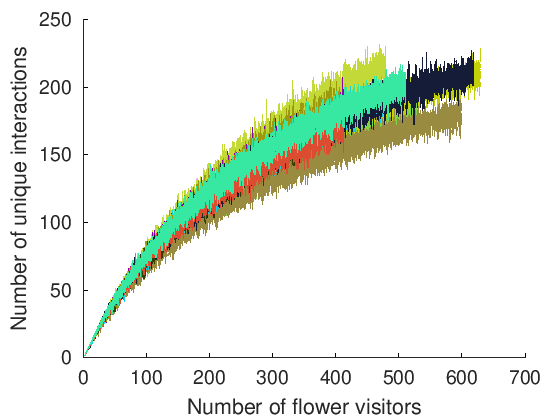

```r
## ALL Together
graphics_toolkit();
available_graphics_toolkits();
loaded_graphics_toolkits();
graphics_toolkit("gnuplot")

addpath(genpath(pwd))
pkg load statistics

%DATA ---------------------
fid = fopen('./src/data/Pampa/Pampa_2020.csv');
in = fscanf(fid,'%c');
fclose(fid);
linesR = regexp(in,'(^,|)([^\n]+)', 'match');
All = char(linesR);
Forest = cell(length(All),1);
wR = unique_no_sort(linesR);
R = char(wR);

#categorize forest type
for k = 1:length(All);
    wHF = regexp(All(k,:),',');
    Forest(k,1) = All(k,1:wHF(1,1)-1);
end
wF = unique_no_sort(Forest);

for n = 2:length(wF);
TypeOutput = zeros(length(R),4);
Type = zeros(1,1);
ForestType = zeros(1,2);
InsectType = zeros(1,1);
xR = zeros(1,1);
wHR1 = zeros(1,1);

wF(1,n)
    cR = cellstr(wF(1,n));
    xR = regexpcell(linesR,cR);
    ForestType = cell(length(xR),1:2);
    %InsectType = cell(length(xR),1);

    for j = 1:length(xR);
        wHR1 = regexp(All(xR(1,j),:),',');
        ForestType(j,1) = All(xR(1,j),wHR1(1,2)+1:wHR1(1,3)-1);%Plant species
        ForestType(j,2) = All(xR(1,j),wHR1(1,4)+1:wHR1(1,5)-1);%Insect species
    end

    %RarefactionI
    N = zeros(1,1);
    Type = unique(ForestType);
    N = length(ForestType);
    UNI = length(Type);

    %All ---
    A = ForestType;
    [B,I,J] = unique(ForestType);

    for u = 1:length(A);
        New(u,1) = J(u,1);
        New(u,2) = J(u+length(A),1);
    end
    Total = unique(New,"rows");
    red=unifrnd(0,1); green=unifrnd(0,1); blue=unifrnd(0,1);

    R=10;
    for rep = 1:R;
        U = zeros(1,2);
        for r = 1:N;
            S = unidrnd(length(New),r,1);
            Sampled = New(S,1:2);
            L = unique(Sampled,"rows");
            U(r,1) = r;
            U(r,2) = length(L);
        end
        hold on
        plot(U(:,1),U(:,2),'k','color',[red green blue],'Markersize',36)
    end%rep
    #pause
end
set(gca,'FontSize',20)
xlabel('Number of flower visitors','fontsize',30)
ylabel('Number of unique interactions','fontsize',30)
```

## Exercise: Do larger Sierras contain more species and interactions than the smaller ones?

```r
## R --------------------
## Rarefaction
## --------------------
# For each site (sierra in Pampa_2020.csv) create a line plot with three lines (one for plants (Plant.AF8.species)
# one for insects (Insect.AF8.species), and unique interactions (Insect.AF8.abundance)).
# The x-axis is time (Day), and the y-axis is count.
# These numbers should be normalized by the site that has the smallest number of samplings.
# One way to do that is only take n random samples from each site, where n is the minimum number of available
# samples among all sites.
# columns 1,2,3,5,6 of the Pampa_2020.csv dataset are needed for this task

# Second plot is site area on the x axis (from area_sp.csv) and the y axis is the number of plants,
# insects, and interactions - with and without rarefaction.
# Third plot: Cumulative plot of number of unique interactions per area.

# install.packages('plyr')
library('plyr')
library('ggplot2')

## 1.1 Normalization
## ------------------
# data loading and preparation
df <- read.csv('src/data/Pampa/Pampa_2020.csv')
# exclude empty columns
df = df[, 1:7]
# Convert Day to Date format
df$Day <- as.Date(df$Day,  tryFormats = c("%d-%m-%Y", "%d/%m/%Y"))

sites = unique(df$Sierra)
min_samples = min(count(df, vars="Sierra")$freq)

# A new table where each all sites have exactly `min_samples` samples.
final_rows = vector()
for (site in sites){
  final_rows = c(final_rows, sample(which(df$Sierra == site), min_samples, replace=FALSE))
}
df2 = df[final_rows, ]

## 1.2 Plot 1
## -----------
```

```r
### R ---
for (site in sites){

  # get flowers per day
  rowsf = which(df2$Sierra == site)
  flowers = count(df2[rowsf,c("Plant.AF8.species", "Day")], vars=c("Day"))
  flowers$Quantity = "Flowers"

  # get insects per day
  rowsi = which((df2$Sierra == site) & (df2$Insect.AF8.species != "No visit"))
  insects = count(df2[rowsi,c("Insect.AF8.species", "Day")], vars=c("Day"))
  insects$Quantity = "Insects"

  # get interactions per day
  rowsi = which(df2$Sierra == site)
  interX = count(df2[rowsi,c("Insect.AF8.abundance", "Day")], vars=c("Day", "Insect.AF8.abundance"))
  interactions = insects
  for (day in unique(interX$Day)){
    rows = interX$Day == day
    c = sum(interX[rows, "Insect.AF8.abundance"] * interX[rows, "freq"])
    interactions[interactions$Day == day, "freq"] = c
  }
  interactions$Quantity = "Interactions"

    # plot
  sitedf = merge(merge(flowers, insects, all=TRUE), interactions, all=TRUE)
  p = ggplot(data=sitedf,
    aes(x=Day, y=freq, color=factor(Quantity))) + geom_line(size=1.2)

    ##ggsave(paste(sit,filename = file.path("R","_abundance.png",sep=""), plot=p))
  ggsave(paste(site,filename = "_abundance.png", sep=""), plot=p)

}
```

[figure not shown]

## Scale-dependence: How do rarefaction curves cross in multilayer mutualistic networks?

```r
### RAREFACTION MULTILAYER mirarefied.m Pampa_2020.csv DistanceMatrixPampaSampled.m
#-----------------------------------------------------------------------
# Multilayer networks - Melian@CH - Multilayer rarefaction OCT NOV 2021
# ----------------------------------------------------------------------
# 0. DATA ------------------------
addpath(genpath(pwd))
fid = fopen('./src/data/Pampa/Pampa_2020.csv');#Open raw data
in = fscanf(fid,'%c');fclose(fid);
linesR = regexp(in,'(^,|)([^\n]+)', 'match');
All = char(linesR);Forest = cell(length(All),1);
wR = unique_no_sort(linesR);R = char(wR);

# 1. List sampled sites
for k = 1:length(All);wHF = regexp(All(k,:),',');
    Forest(k,1) = All(k,1:wHF(1,1)-1);
end
wF = unique_no_sort(Forest)#pause

#Distance matrix
DistanceMatrixPampaSampled;
dis
#---------------------------------
```

```
wF =
{
  [1,1] = Sierra
  [1,2] = Piedra Alta
  [1,3] = Difuntito
  [1,4] = Difuntos
  [1,5] = Cinco cerros
  [1,6] = Volcan
  [1,7] = La Chata
  [1,8] = Barrosa
  [1,9] = La Brava
  [1,10] = Vigilancia
  [1,11] = El Morro
  [1,12] = La Paja
  [1,13] = Amarante
}

dis =

 Columns 1 through 8:

         0    6.0000   42.0000    3.7000   20.6000   15.9000   15.7000   31.6500
    6.0000         0   35.9000    1.4000   16.0000   16.1000   12.0000   25.7000
   42.0000   35.9000         0   36.0000   12.0000   41.7000   30.6000    9.7000
    3.7000    1.4000   36.0000         0   16.0000   18.3000   14.7000   25.8000
   20.6000   16.0000   12.0000   16.0000         0   20.5000   10.4000    4.0000
   15.9000   16.1000   41.7000   18.3000   20.5000         0    8.6000   32.5000
   15.7000   12.0000   30.6000   14.7000   10.4000    8.6000         0   22.3000
   31.6500   25.7000    9.7000   25.8000    4.0000   32.5000   22.3000         0
   26.8000   23.0000   11.7000   22.0000    0.8000   20.0000   10.5000    1.1500
    9.1000   15.0000   50.0000   13.5000   28.4000   14.9000   20.2000   40.4000
    2.3000    3.0000   39.4000    3.8000   18.0000   15.0000   13.4000   29.1000
   11.5000   12.4000   41.8000   14.5000   19.9000    2.6000    8.8000   32.0000

 Columns 9 through 12:

   26.8000    9.1000    2.3000   11.5000
   23.0000   15.0000    3.0000   12.4000
   11.7000   50.0000   39.4000   41.8000
   22.0000   13.5000    3.8000   14.5000
    0.8000   28.4000   18.0000   19.9000
   20.0000   14.9000   15.0000    2.6000
   10.5000   20.2000   13.4000    8.8000
    0.9000   40.4000   29.1000   32.0000
         0   32.0000   24.1000   21.0000
   32.0000         0   11.3000   11.5000
   24.1000   11.3000         0   10.8000
   21.0000   11.5000   10.8000         0
```

#### http://mkivela.com/pymnet/visualizing.html

##### import scipy

##### import networkx

##### import pymnet

##### from pymnet import *

##### net = models.er_multilayer(5,2,0.2)

##### fig = draw(net,show=True)

[figure not shown]

##### from IPython.display import Image

##### Image("Pictures/Figure2.png")

```
m = 3
ans =
{
  [1,1] = Difuntito
}

m = 4
ans =
{
  [1,1] = Difuntos
}

m = 5
ans =
{
  [1,1] = Cinco cerros
}

m = 6
ans =
{
  [1,1] = Volcan
}

m = 7
ans =
{
  [1,1] = La Chata
}

m = 8
ans =
{
  [1,1] = Barrosa
}

m = 9
ans =
{
  [1,1] = La Brava
```

[output cut: 274 more lines]

```
{
  [1,1] = El Morro
}

m = 12
ans =
{
  [1,1] = La Paja
}

m = 12
ans =
{
  [1,1] = La Paja
}
```

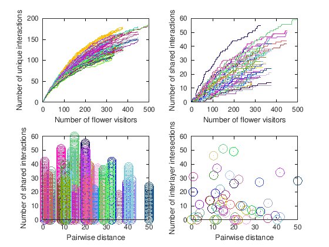

```r
#mirarefied.m ALL TOGETHER
graphics_toolkit();
available_graphics_toolkits();
loaded_graphics_toolkits();
graphics_toolkit("gnuplot")

addpath(genpath(pwd))
pkg load statistics
count = 0;#for intersection

# 2. Loop shared interactions sites(n,m)
for n = 2:length(wF)-1;
red1=unifrnd(0,1); green1=unifrnd(0,1); blue1=unifrnd(0,1);
wF(1,n);n;
        # Site n
        ForestType1 = zeros(1,2);xR1 = zeros(1,1);wHR1 = zeros(1,1);FT1 = zeros(1,1);
        cR1 = cellstr(wF(1,n));xR1 = regexpcell(linesR,cR1);
        ForestType1 = cell(length(xR1),1:2);

        for j = 1:length(xR1);
            wHR1 = regexp(All(xR1(1,j),:),',');
            ForestType1(j,1) = All(xR1(1,j),wHR1(1,2)+1:wHR1(1,3)-1);%Plant species
            ForestType1(j,2) = All(xR1(1,j),wHR1(1,4)+1:wHR1(1,5)-1);%Insect species
        end

    for m = n+1:length(wF)-1;
    m
        red2=unifrnd(0,1); green2=unifrnd(0,1); blue2=unifrnd(0,1);
        red3=unifrnd(0,1); green3=unifrnd(0,1); blue3=unifrnd(0,1);
        wF(1,m)


        # Site m
        ForestType2 = zeros(1,2);xR2 = zeros(1,1);wHR2 = zeros(1,1);FT2 = zeros(1,1);
        cR2 = cellstr(wF(1,m));xR2 = regexpcell(linesR,cR2);
        ForestType2 = cell(length(xR2),1:2);

        for j = 1:length(xR2);
            wHR2 = regexp(All(xR2(1,j),:),',');
            ForestType2(j,1) = All(xR2(1,j),wHR2(1,2)+1:wHR2(1,3)-1);#Plant species
            ForestType2(j,2) = All(xR2(1,j),wHR2(1,4)+1:wHR2(1,5)-1);#Insect species
        end

   #Remove No Visit
   removeIndex1 = strcmp(ForestType1(:,2),'No visit');
   ForestType1(removeIndex1,:) = [];

   removeIndex2 = strcmp(ForestType2(:,2),'No visit');
   ForestType2(removeIndex2,:) = [];
   #pause

    #Concatenate interactions to unique
    FT1 = strcat(ForestType1(:,1),{' '},ForestType1(:,2));
    FT2 = strcat(ForestType2(:,1),{' '},ForestType2(:,2));
    #W = intersect(FT1,FT2);#shared unique

      # 3. Pairs alpha-beta interaction curves
    M=zeros(1,1);W12=zeros(1,2);U1=zeros(1,2);U2=zeros(1,2);UN1 = zeros(1,1);UN2 = zeros(1,1);w=zeros(1,1);
    S1 = zeros(1,1);S2 = zeros(1,1);L1 = cell(1,1);L2 = cell(1,1);In = zeros(1,2);
    M = min(length(FT1),length(FT2));#account equal sampling size
    for r = 1:M;
        S1 = unidrnd(length(FT1),1,1)';L1(r,1) = FT1(S1,1);UN1 = unique(L1(:,1));
        U1(r,1) = r;U1(r,2) = length(UN1);

        S2 = unidrnd(length(FT2),1,1)';L2(r,1) = FT2(S2,1);UN2 = unique(L2(:,1));
        U2(r,1) = r;U2(r,2) = length(UN2);

        w = intersect(UN1,UN2);#shared unique
        W12(r,1) = length(w);
        W12(r,2) = dis(n,m);#Distance ij
    end

      # 4. Intersections interlayer
    count = count + 1;q = zeros(1,1);
    In(count,1) = dis(n,m);
    intersection=find(U1(:,2)==U2(:,2));
    q = find(intersection) >= 10;
    In(count,2) = nnz(q);

    #. 5. PLOT
    hold on
    subplot(2,2,1)
    plot(U1(:,1),U1(:,2),'k','color',[red1 green1 blue1],'Markersize',36)
    hold on
    plot(U2(:,1),U2(:,2),'k','color',[red2 green2 blue2],'Markersize',36)
    set(gca,'FontSize',12)
    xlabel('Number of flower visitors','fontsize',12)
    ylabel('Number of unique interactions','fontsize',12)

    hold on
    subplot(2,2,2)
    plot(U2(:,1),W12(:,1),'k','color',[red3 green3 blue3],'Markersize',36)
    set(gca,'FontSize',12)
    xlabel('Number of flower visitors','fontsize',12)
    ylabel('Number of shared interactions','fontsize',12)

    hold on
    subplot(2,2,3)
    plot(W12(:,2),W12(:,1),'ko','color',[red3 green3 blue3],'Markersize',14)
    set(gca,'FontSize',12)
    xlabel('Pairwise distance','fontsize',12)
    ylabel('Number of shared interactions','fontsize',12)

    hold on
    subplot(2,2,4)
    plot(In(:,1),In(:,2),'ko','color',[red3 green3 blue3],'Markersize',14)
    set(gca,'FontSize',12)
    xlabel('Pairwise distance','fontsize',12)
    ylabel('Number of interlayer intersections','fontsize',12)

    #hold off
   end#m Sites
end#n Sites
```

[figure not shown]

## Centrality: How do we account for spatial and interaction network position?

### Multilayer betweenness centrality

Given : $\overrightarrow{B}(B_{ij})$, where $i$ is species $i$ and $j$ is the number of sites with species $i$ having at least one interacting partner

$$ \overrightarrow{B}(B_{ij}) = \Bigg[ {\small normal_{S}} \Bigg( \Large\sum_{s \neq j \neq t}\frac{\sigma_{st(j)}}{\sigma_{st}} \Bigg) \times {\small normal_{M}} \Bigg(\Large\sum_{s' \neq i \neq t'}\frac{\sigma_{s't'(i)}}{\sigma_{s't'}} \Bigg) \Bigg]$$

where $\sigma_{st}$ is total number or shortest paths from node $s$ to node $t$ and $\sigma_{st(j)}$ is the number of those paths that pass through $j$ (or $i$). Normalizing the metrics we obtain

$normal_{S}$ = $\frac{S(j) - \min(\overrightarrow{S})}{\max(\overrightarrow{S}) - \min(\overrightarrow{S})}$ for the spatial network and

$normal_{M}$ = $\frac{M(i) - \min(\overrightarrow{M})}{\max(\overrightarrow{M}) - \min(\overrightarrow{M})}$ for the interaction network,

which results in:

- max(normal) = 1
- min(normal) = 0

```r
#WARNING! This function is called by PlantBetweennessRandom.m

#This function returns the betweenness of all nodes in an adjacency (transformed from a bipartite)
# Accounts for site centrality
# Betweenness centrality measure: number of shortest paths running through a vertex.

#INPUTS: Random ADJ data - plant-pollinator network
#INPUTS: Adjacency matrix (nxn)

#OUTPUTS: betweeness vector for each node (1xn)

#Routines used: numNodes.m, adj2adjL.m, simpleDijkstra.m, findAllShortestPaths.m
#-------------------------------------------------------------------------------------

# https://en.wikipedia.org/wiki/Betweenness_centrality
# Example with a bipartite graph

graphics_toolkit();
available_graphics_toolkits();
loaded_graphics_toolkits();
graphics_toolkit("gnuplot")

addpath(genpath(pwd))
pkg load statistics

#matrix adj comes from mbetweenrandom.m
n = numNodes(adj);
w = size(adj);
%coord
xy = zeros(w(1,1),2);
for z = 1:length(xy);
    xy(z,1) = unidrnd(100);
    xy(z,2) = unidrnd(100);
end
#plot
#clf;
#gplot (adj, xy, "o-");
#set (get (gca, ("children")), "markersize", 12);
#title ("gplot() of bit2uni Adjacency matrix");

spaths=inf(n,n);
betw = zeros(1,n);
adjL = adj2adjL(adj);

for i = 1:n;
    uB = simpleDijkstra(adj,i);
    for l=1:n;
        if i==l; continue; end

        [allPaths, ~] = findAllShortestPaths(adjL,i,l, uB(l), allPaths={},path=[]);
        spaths(i,l) = length(allPaths);

        % for all paths in allPaths, parse out the path:
        for p=1:length(allPaths)
            path = strsplit(allPaths{p},'-');
            pathvec = [];
            for x=2:length(path)  % skip the first one
                pathvec = [pathvec str2num(path{x})];
            end
            betw(pathvec(2:length(pathvec)-1)) = betw(pathvec(2:length(pathvec)-1)) + 1/spaths(i,l);
        end
    end  % end of j=1:n
end      % end of i=1:n

#Some outputs
#Total distance vs centrality
#D=sum(dis,2);b=betw';
#plot(D,b,'o')
```

```r
#----------------------------------------------------------------------------------
#mbetweenrandom.m : Multilayer rarefaction random
#Betweenness centrality from spatial and interaction networks
#DEPENDENCIES
#PlantBetweennessRandom.m

# Melian@CH, Multilayer networks OCT NOV 2021
#----------------------------------------------------------------------
graphics_toolkit();
available_graphics_toolkits();
loaded_graphics_toolkits();
graphics_toolkit("gnuplot")

addpath(genpath(pwd))
pkg load statistics

# Make a random spatial matrix
s1 = 10;s2 = 10;adjS = rand(s1,s2)>.75;

# Compute betwenneess each site
S = numNodes(adjS);spaths=inf(s1,s2);
betwS = zeros(1,s1);adjL = adj2adjL(adjS);

for i=1:s1;
    uB = simpleDijkstra(adjS,i);
    for j=1:s2;
        if i==j; continue; end
        [allPaths, ~] = findAllShortestPaths(adjL,i,j, uB(j), allPaths={},path=[]);
        spaths(i,j) = length(allPaths);
        # for all paths in allPaths, parse out the path:
        for pat=1:length(allPaths)
            path = strsplit(allPaths{pat},'-');
            pathvec = [];
            for x=2:length(path) # skip the first one
                pathvec = [pathvec str2num(path{x})];
            end
            betwS(pathvec(2:length(pathvec)-1)) = betwS(pathvec(2:length(pathvec)-1)) + 1/spaths(i,j);
        end
    end  # end of j=1:s1
end      # end of i=1:s2

#Presence/Absence plant matrix
pl = 10;PA = rand(pl,s1)>.75
BC = zeros(pl,s1);

for ii = 1:pl;#loop plant i
ii
    red=unifrnd(0,1); green=unifrnd(0,1); blue=unifrnd(0,1);#def color each species i
    for jj = 1:s1;
        if PA(ii,jj) == 1;
           a = unidrnd(15);A = rand(pl,a)>.75;# Make a random MxN adjacency bipartite matrix
           adj = [zeros(pl,pl), A;A', zeros(a,a)];# Expand out to symmetric (M+N)x(M+N) matrix
           PlantBetweennessRandom;
           Bc(ii,jj) =  betwS(1,jj) * betw(1,ii);
        else
           PA(ii,jj) = 0;
        end
    end#site
Bci = sort(Bc(ii,:),2,'descend');#Rank output
rank = 1:length(Bci);
hold on
plot(rank,Bci,'k','color',[red green blue],'Markersize',12)
set(gca,'FontSize',12)
xlabel('Rank species centrality','fontsize',12)
ylabel('Betweenness','fontsize',12)
end
```

[output not shown]

[output cut: 88 more lines]

[output not shown]

[figure not shown]

1. 12

2. 12

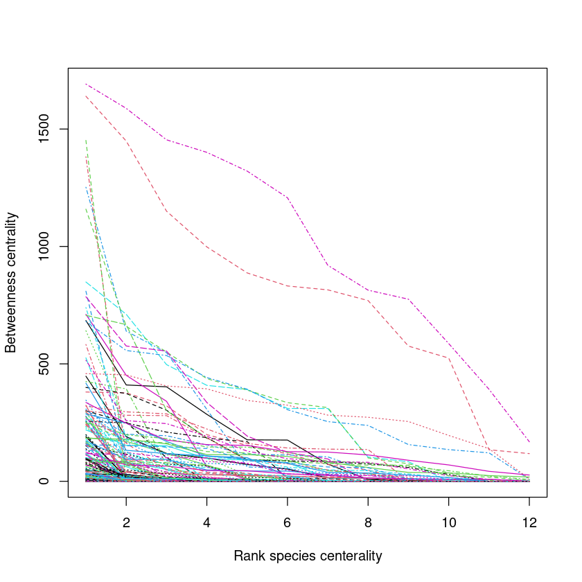

```r
#٫ --------------------------
## 2. Betweenness centrality
#٫ --------------------------

# 2.1 Create a network of sites where a node is a site and a link is present when distance (from DistanceMatrixPampa.csv dataset) between two sites is less than a threshold. Then calculate a betweenness centrality score for each node.
# 2.2 go through the list of each plant and insect, and sum the centrality scores of all the sites in which the species is present. Create a bar plot from these centrality scores for all plants and insects.
# Plant/insect centrality: For each site, you have a plant/insect network. Get a centrality score for each plant for each site.
# multiply the centrality of each species within sites to the centrality of the sites in which it appears. That will be the centrality score of the species.
# Plot the distribution of the centralities of a species.

## 2.1 Site network
library(igraph)
library(comprehenr)
connectedness_threshold = 10

ddf = read.csv('src/data/Pampa/DistanceMatrixPampa.csv')
site_names = c("Sierra", "Difuntos", "Valdez", "La Brava", "Volcan", "Vigilancia", "Volcancito", "Paulino", "Bachicha", "Difuntito", "Cinco cerros", "Barrosa", "La Paja", "Piedra Alta", "Los Pinos", "Amarante", "La Chata", "El Morro", "La Larga")
ddf[,1] = site_names[2:ncol(ddf)]
colnames(ddf) = site_names

# Choose only sites for which there are plant/insect sampling
sampled_sites = unique(df2$Sierra)
valid_sites = to_vec(for (i in 1:ncol(ddf)) if (site_names[i] %in% sampled_sites) i)  # needs comprehenr

# create a distance matrix
distmat = as.matrix(ddf[valid_sites-1,valid_sites])
dim(distmat)

# Create an adjacency matrix
adjmat = matrix(0, nrow(distmat), ncol(distmat))
connections = distmat <= connectedness_threshold
adjmat[connections] = 1

# create the graph
site_graph = graph_from_adjacency_matrix(distmat, mode="undirected")

# graph's betweenness centrality
site_btwn = betweenness(site_graph)

## 2.2 Within network betweenness centralities
plants = unique(df2$Plant.AF8.species)
insects = unique(df2$Insect.AF8.species)
all_species = c(plants,insects)
all_betweenness = matrix(0.0, length(plants) + length(insects), length(valid_sites))
for (ind in 1:length(valid_sites)){
  site = site_names[valid_sites[ind]]

  rowss = which((df2$Sierra == site)  & (df2$Insect.AF8.species != "No visit"))
  interactions = count(df2[rowss,c("Plant.AF8.species", "Insect.AF8.species", "Insect.AF8.abundance")], vars=c("Plant.AF8.species", "Insect.AF8.species"))

  # create a graph
  adjlist = interactions[, 1:2]

  site_plants = unique(adjlist[,1])
  site_insects = unique(adjlist[,2])
  alls = c(site_plants, site_insects)
  nallspecies = length(alls)
  alladjmat = matrix(0, nallspecies, nallspecies)

  for (row in 1:nrow(adjlist)){
    pind = which(alls == adjlist[row, 1])[1]
    iind = which(alls == adjlist[row, 2])[1]
    alladjmat[pind, iind] = 1
  }

  inx_graph = graph_from_adjacency_matrix(alladjmat, mode="undirected")
  btwn = betweenness(inx_graph)

  for (i in 1:length(alls)){
    ff = which(all_species == alls[i])[1]
    all_betweenness[ff, ind] = btwn[i]
  }
}

# plot
sorted_per_row = matrix(0.0, length(plants) + length(insects), length(valid_sites))
for (row in 1:nrow(all_betweenness)){
  sorted_per_row[row,] = sort(all_betweenness[row, ], decreasing=TRUE)
}

#pdf("plots/species_betweenness_centrality.pdf")
matplot(t(sorted_per_row), type="l", ylab="Betweenness centrality", xlab="Rank species centerality")
#dev.off()
```

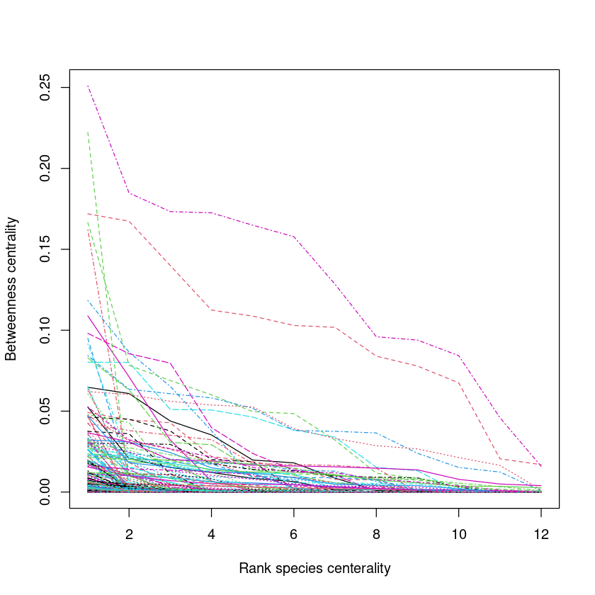

```r
# normalize the betweenness values so that they are between 0 and 1

normalized_betweenness = matrix(0.0, length(plants) + length(insects), length(valid_sites))
sum_betweenness = colSums(all_betweenness)
for (row in 1:nrow(all_betweenness)){
  normalized_betweenness[row,] = all_betweenness[row, ] / sum_betweenness
}

# plot
sorted_per_row_normalized = matrix(0.0, length(plants) + length(insects), length(valid_sites))
for (row in 1:nrow(normalized_betweenness)){
  sorted_per_row_normalized[row,] = sort(normalized_betweenness[row, ], decreasing=TRUE)
}

#pdf("plots/species_betweenness_centrality_normalized.pdf")
matplot(t(sorted_per_row_normalized), type="l", ylab="Betweenness centrality", xlab="Rank species centerality")
#dev.off()
```

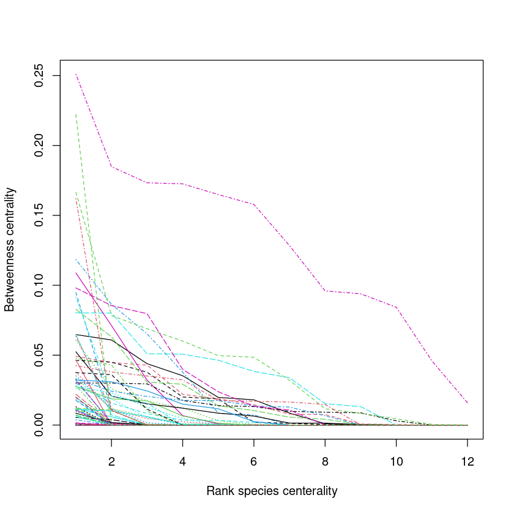

```r
#pdf("plots/species_betweenness_centrality_normalized_plants.pdf")
matplot(t(sorted_per_row_normalized[1:length(plants),]), type="l", ylab="Betweenness centrality", xlab="Rank species centerality")
#dev.off()
```

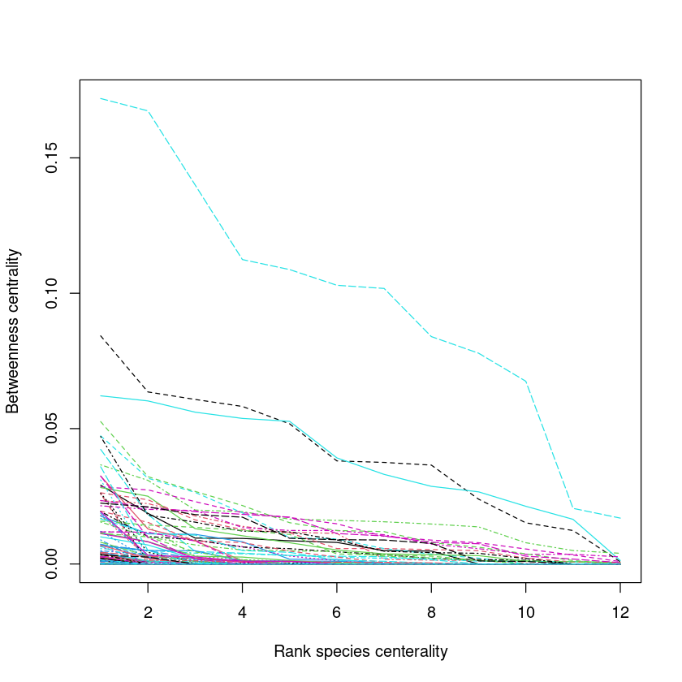

```r
#pdf("plots/species_betweenness_centrality_normalized_insects.pdf")
matplot(t(sorted_per_row_normalized[(length(plants)+1):length(all_species),]), type="l", ylab="Betweenness centrality", xlab="Rank species centerality")
#dev.off()
```

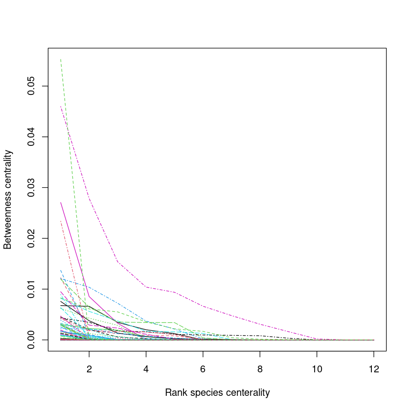

```r
# normalize the sites' betweenness
site_btwn_normalized = site_btwn / sum(site_btwn)

# multiply sites' betweenness to species' betweenness
normalized_betweenness_multiplied = matrix(0.0, length(plants) + length(insects), length(valid_sites))
for (row in 1:nrow(all_betweenness)){
  normalized_betweenness_multiplied[row,] = normalized_betweenness[row, ] * site_btwn_normalized
}

# plot
sorted_normalized_betweenness_multiplied = matrix(0.0, length(plants) + length(insects), length(valid_sites))
for (row in 1:nrow(normalized_betweenness_multiplied)){
  sorted_normalized_betweenness_multiplied[row,] = sort(normalized_betweenness_multiplied[row, ], decreasing=TRUE)
}

#pdf("plots/species_betweenness_centrality_normalized_multiplied_plants.pdf")
matplot(t(sorted_normalized_betweenness_multiplied[1:length(plants),]), type="l", ylab="Betweenness centrality", xlab="Rank species centerality")
#dev.off()
```

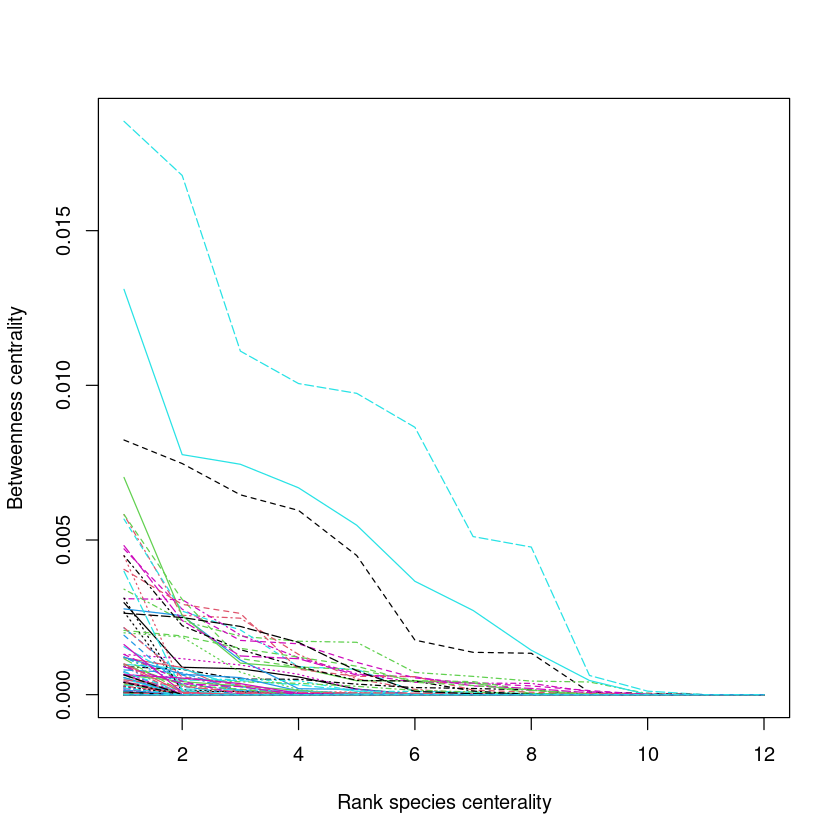

```r
#pdf("plots/species_betweenness_centrality_normalized_multiplied_insects.pdf")
matplot(t(sorted_normalized_betweenness_multiplied[(length(plants)+1):length(all_species),]), type="l", ylab="Betweenness centrality", xlab="Rank species centerality")
#dev.off()
```

### Take home message

- Simplest rarefaction accounting for sampling size ##### Do larger islands contain higher number of interactions and species than the smaller ones?
- Numbers of interaction crossings among sites ##### Do the number of crossings decay with distance among sites?
- Rank centrality distribution in multilayer networks ##### How does rank centrality distribution decay in multilayer network?